# PA1_template.Rmd

owilks

March 29, 2017

# Prepping all of the relevant data

Firstly we need to retrieve the data from the website and load it into your system along with the library dependencies. (Including caching the data to increase efficiency)

```r
knitr::opts_chunk$set(echo = TRUE, cache=TRUE)
library(ggplot2)
library(reshape2)
download.file("https://d396qusza40orc.cloudfront.net/repdata%2Fdata%2Factivity.zip","repdata%2Fdata%2Factivity.zip")
unzip("repdata%2Fdata%2Factivity.zip")
activity <-read.csv("activity.csv")
```

# Part 1 (What is mean total number of steps taken per day?)

Initially we create a subset that ignores the missing values for our plot and then proceed. This subset can be used until we replace the missing values later on in the report.

```r
#subsetting out the NA values
val <- !is.na(activity$steps)
actsub <- activity[val,]
```

Afterwards we can move on towards answering the questions

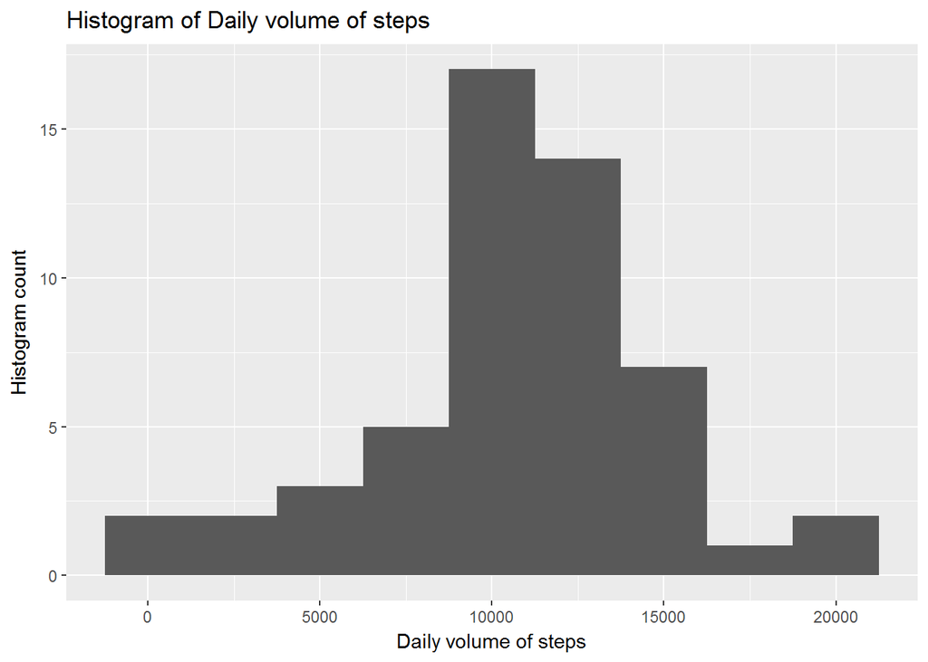

```r
dstep <- with(actsub, tapply(steps,date,sum))
dstep<-dstep[!is.na(dstep)]
ggplot()+aes(dstep)+geom_histogram(binwidth=2500)+labs(y="Histogram count",x="Daily volume of steps")+ggtitle("Histogram of Daily volume of steps")
```

```r
dsmean <- mean(dstep)
dsmed <- median(dstep)
```

# Part 2 (What is the average daily activity pattern?)

- Make a time series plot (i.e. type = “l”) of the 5-minute interval (x-axis) and the average number of steps taken, averaged across all days (y-axis)
- Which 5-minute interval, on average across all the days in the dataset, contains the maximum number of steps?

Both of those questions are answered below!

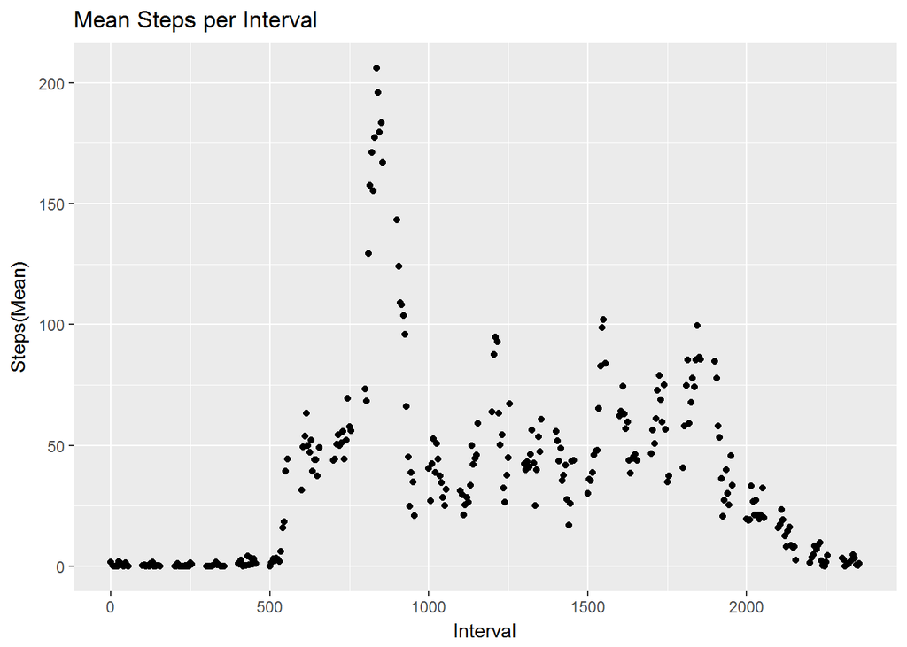

```r
istep <- aggregate(actsub$steps,by=actsub["interval"],FUN=mean)
names(istep) <- c("int","steps")
ggplot(istep,aes(int,steps))+geom_point()+labs(x="Interval",y="Steps(Mean)")+ggtitle("Mean Steps per Interval")
```

```r
#Calculating the max and plugging it back into the index of the dataframe
intmax <-istep[which.max(istep$steps),1]
```

The interval with the largest amount of average steps is 835.

# Part 3 (Imputing missing values)

Note that there are a number of days/intervals where there are missing values (coded as NA). The presence of missing days may introduce bias into some calculations or summaries of the data.

The amount of missing values currently is 2304.

To get some more data accuracy I thought it might be more reflective of the overall data set if we added the means of each interval (data that we’d already calculated in one of the previous steps).

```r
#Transformation by using for/if loops to test each element in the activity steps group for whether it's NA and then to find the relevant value within the "isteps" (Average steps per interval) data frame.

for(i in 1:length(activity$steps)){
    if(is.na(activity[i,1])){
         for(j in 1:length(istep$int)){
               if(istep[j,1]==activity[i,3]){
                     activity[i,1]<-round(istep[j,2])
                 }

              }
      }
}
```

Now that the transformation is done we can effectively repeat the process from the first question.

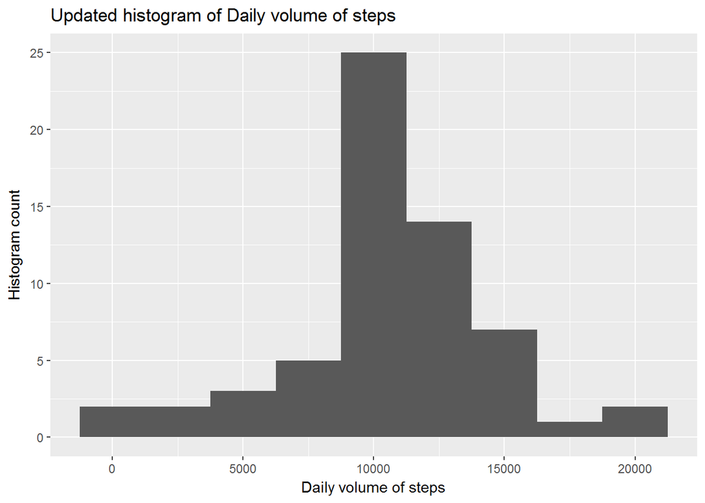

```r
dstep2 <- with(activity, tapply(steps,date,sum))
dstep2<-dstep2[!is.na(dstep2)]
ggplot()+aes(dstep2)+geom_histogram(binwidth=2500)+labs(y="Histogram count",x="Daily volume of steps")+ggtitle("Updated histogram of Daily volume of steps")
```

```r
dsmean2 <- mean(dstep2)
dsmed2 <- median(dstep2)
```

# Part 4 (Are there differences in activity patterns between weekdays and weekends?)

- Create a new factor variable in the dataset with two levels – “weekday” and “weekend” indicating whether a given date is a weekday or weekend day.
- Make a panel plot containing a time series plot (i.e. type = “l”) of the 5-minute interval (x-axis) and the average number of steps taken, averaged across all weekday days or weekend days (y-axis).

The relevant data transformation and plot code is below, although I’m sure there was a more efficient way to create that factor.

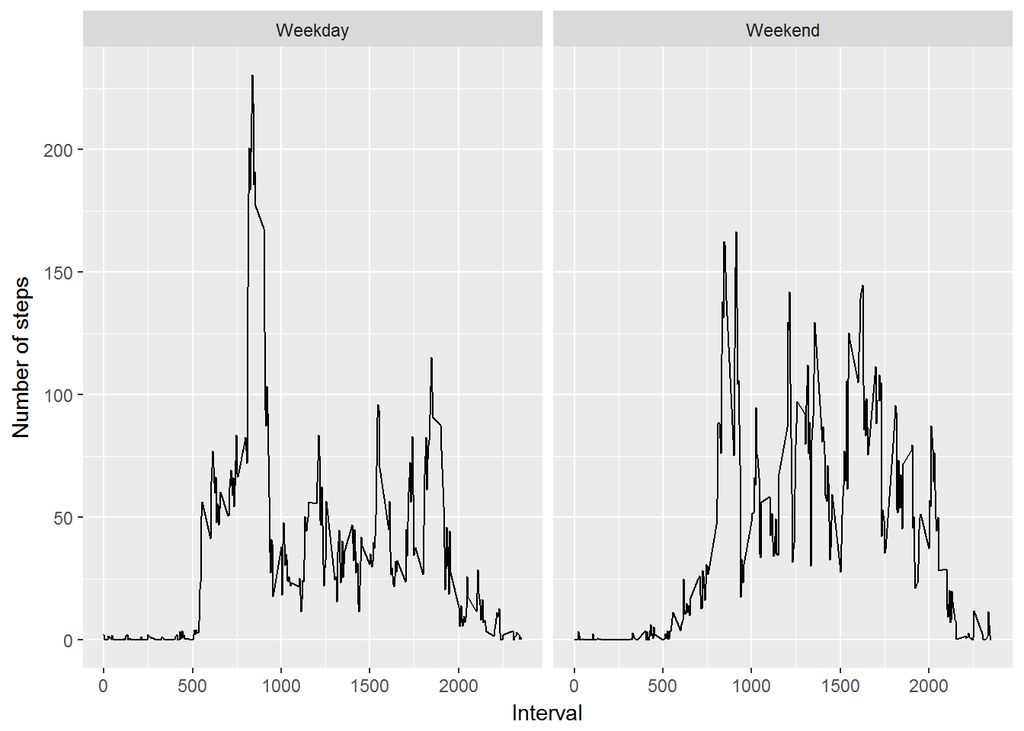

```r
activity$weekday <- weekdays(as.Date(activity$date))
activity[activity$weekday%in%c("Monday","Tuesday","Wednesday","Thursday","Friday"),5]<-"Weekday"
activity[activity$weekday%in%c("Saturday","Sunday"),5]<-"Weekend"
names(activity) <- c("steps","date","interval","weekday","dtype")
activity$dtype <- as.factor(activity$dtype)
idstep <- aggregate(activity$steps,by=c(activity["dtype"],activity["interval"]),FUN=mean)
ggplot(idstep)+aes(interval,x)+geom_line()+facet_grid(~dtype)+labs(y="Number of steps",x="Interval")
```

Thanks for reading!

owilks